# 03 Progresión Aritmética

2024-01-22

## Tema 1: Progresiónes y series

- **Series**: Es una secuencia de valores que se suman o restan para obtener un valor final.
- **Progresión aritmética**: La diferencia común entre los términos consecutivos es constante y sigue una secuencia numérica ordenada.
- **Progresión geométrica**: cada término se obtiene multiplicando el término anterior por una constante.

## Tema 1.2 Progresión Aritmética (1)

- Las reservas iniciales Shell son \(100,000\) millones de litros.
- Si la diferencia entre año y año es de \(d=5000\) millones de litros.
- Demuestra que las reservas de petróleo crudo siguen una progresión aritmética creciente.
- Calcula el tamaño de las reservas en el año 4

## Tema 1.2 Progresión Aritmética (1)

\(d=5000\)

\(a_1 = 100000\)

\(S_1 = a_1\)

\(S_2 = S_1+d\)

\(S_3 = S_2+d\)

## Tema 1.2 Progresión Aritmética (1)

\(S_3 = (S_1+d)+d\)

\(S_3 = (S_1)+d+d\)

\(S_3 = (a_1)+d+d\)

\(S_3 = a_1 + 2d\)

\(S_3 = a_1 + (3-1)d\)

\(\vdots\)

\(S_n = a_1 + (n-1)d\)

## Tema 1.2 Progresión Aritmética (1)

\(S_n = a_1 + \times (n-1)d\)

-¿Cuál sería el tamaño de las reservas en el año 4? \(S_4 = 100000 \times (4-1)*5000=115000\)

## Tema 1.2 Progresión Aritmética (1)

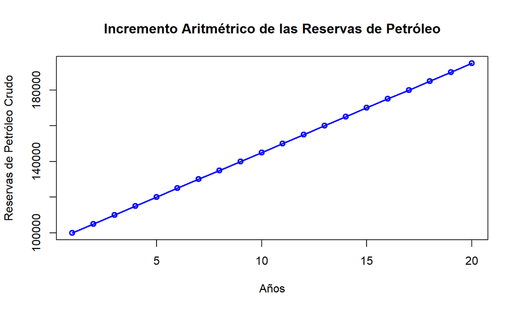

## Tema 1.2 Progresión Aritmética (1)

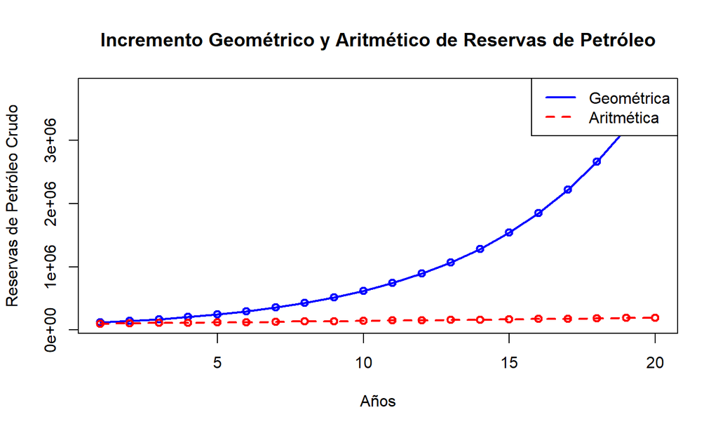

## Tema 1.2 Progresión Aritmética (1)

- ¿Cuál es la suma acumulada de las reservas de petróleo hasta el año 4?

El valor de la progresión acumulado para cada año:

\[S_n'=\sum_{n=1}^{n} (a_1 + (n-1) \times d)\] También puede usar la fórmula general:

\[S_n' = \frac{n}{2}(2a_1 + (n-1)d)\]

## Tema 1.2 Progresión Aritmética (1)

- ¿Cuál es la suma acumulada de las reservas de petróleo hasta el año 4?

\[\begin{align*} S_4' &= (100000 + 0 \times 5000) + (100000 + 1 \times 5000) \\ &+ (100000 + 2 \times 5000) + (100000 + 3 \times 5000) \\ &=430000\\ \end{align*}\]

```
## [1] 430000
```

```
## [1] 430000
```

## Tema 1.2 Progresión Aritmética (2)

- Las acciones de una empresa se emiten inicialmente a un precio de 100 USD.
- El valor de las acciones aumenta en un 10 % del valor incial por año.
- ¿Que precio tendrá en el año 15?

## Tema 1.2 Progresión Aritmética (2)

\(a_1=100\) \(d=100*.10\) \(d=10\)

\(S_n = a_1 + \times (n-1)d\)

En 15 años: \(100+(15-1)*10 = 240\) USD

## Tema 1.2 Progresión Aritmética (3)

- Comprueba que esta progresión de inversión sigue una progresión aritmética: \(3000, 6000, 9000, 12000, 15000, 18000\)

## Tema 1.2 Progresión Aritmética (3)

\(a_1=3000\)

\(S_1 = a_1\) \(S_2 = a_1+d\) \(S_2 = 3000+3000\) \(S_3 = 3000+2*3000\) \(S_n = 3000+(n-1)*3000\)

## Tema 1.2 Progresión Aritmética (4)

- Marco invierte \(2000\) USD en esta cuenta de inversión.
- Cada año crece su inversión al \(2\)% de su inversión inicial.
- Durante esos 5 años, hay una inflación del 2.5% anual.
- Tasa de interés anual \(j=0.02\)
- Tasa de inflación anual \(i=0.025\)
- El cambio porcentual anual en términos reales es

\(r = j - i=-0.005=-0.5\%\)

- ¿Cuál es el valor en términos reales de la inversión de Marco después de esos 5 años?

## Tema 1.2 Progresión Aritmética (4)

- Una reducción anual del \(-0.5\%\) de la inversión inicial:

\(d=-0.005*2000=-10\)

\(S_5 = 2000+(5-1)*-10=1960\) USD

## Tema 1.2 Progresión Aritmética (5)

- Imagina que esta progresión representa la deuda anual de una persona en miles de pesos:

\[2, 5, 8, 11, 14,\dots \]

Deduce la progresión aritmética y calcula la deuda en el año 7.

## Tema 1.2 Progresión Aritmética (5)

\(a_1=2\)

\(S_1=a_1\)

\(S_2= S_1 + d\)

\(5= 2 + d\)

\(d= 5-2=3\)

La progresión: \(S_n = a_1+(n-1)*3\)

Deuda en el año 7: \(S_7 = 2+(6)*3=20\) miles de pesos

## Tema 1.2 Progresión Aritmética (6)

Imagina que esta progresión representa el costo anual del seguro de gastos médicos mayores en miles de pesos:

\(5, 12, 19, 26, 33, 40,\dots\)

Deduce la progresión aritmética y calcula el costo en el año 10.

## Tema 1.2 Progresión Aritmética (6)

\(a_1=5\)

\(S_1=a_1\)

\(S_2= S_1 + d\)

\(12= 5 + d\)

\(d= 12-5=7\)

La progresión: \(S_n = a_1+(n-1)*7\)

Costo del seguro en el año 10: \(S_{10} = 5+(9)*7=68\) miles de pesos.

## Tema 1.2 Progresión Aritmética (7)

- Imagina que esta progresión representa el valor de un terreno que se aprecia.
- A un 10% de su valor inicial cada año.
- El valor inicial del terreno es de \(50000\) USD.

¿Cuál será el valor del terreno en 8 años?

## Tema 1.2 Progresión Aritmética (7)

\(a_1=50000\)

\(d=50000*0.1=5000\)

La progresión: \(S_n = a_1+(n-1)*5000\)

El valor del terreno en el año 8: \(S_{8} = 50000+(7)*5000=85000\) USD.

## Tema 1.2 Progresión Aritmética (8)

- Imagina que decides ahorrar cierta cantidad de dinero cada mes.
- Supongamos que el primer mes ahorras \(1000\), el segundo mes \(1500\), el tercer mes \(2000\) y así sucesivamente.

¿Cuanto sería tu ahorro acumulado despues de 4 años?

## Tema 1.2 Progresión Aritmética (8)

\(d=500\)

\(a_1=1000\)

\(n=12*4=48\)

La suma acumulada del ahorro en pesos \[ S_n' = \frac{48}{2}(2 \times 1000 + (n-1) \times 500)=612000 \]

## Tema 1.2 Progresión Aritmética (9)

- Supongamos una empresa tiene gastos de \(20\) millones de pesos (mdp) mensuales.
- Sin embargo sus ingresos mensuales incrementan de 5 mdp por mes.

¿Cuál será el balance acumulado después de 12 meses?

## Tema 1.2 Progresión Aritmética (9)

Donde:

- \(a_1\) es el gasto mensual (-20 mdp).
- \(d\) es el ingreso mensual (5 mdp).
- \(n\) es el número de meses (12).

## Revisión

## Revisión

```
## Versión: 23/01/2024
```

## Bibliografía

## Bibliografía

- Petters, A. O., & Dong, X. (2016). An introduction to mathematical finance with applications. New York, NY: Springer, 10,978-1.
- Cuemath. (s.f.). Sum of Arithmetic Sequence Formula. Recuperado de [https://www.cuemath.com/sum-of-arithmetic-sequence-formula/]